# Neuro analyses

```r
library(dplyr)
library(tidyr)
library(readr)
library(ggplot2)
library(readxl)
library(httr)
library(rcartocolor)
library(stringr)
library(forcats)
library(purrr)
theme_set(theme_bw() + theme(legend.title = element_blank()))
source('utils.R')
```

## Download data

```r
github_link <- 'https://raw.githubusercontent.com/covidclinical/Phase1.1AggregateDataPerSite/master/'
demo_link <- paste0(github_link, 'Demographics_persite_fakeID.csv')
diag_link <- paste0(github_link, 'Diagnoses_persite_fakeID.csv')

temp_file_1 <- temp_file_2 <- tempfile(fileext = ".csv")
req <- GET(demo_link,
          # authenticate using GITHUB_PAT
           authenticate(Sys.getenv("GITHUB_PAT"), ""),
          # write result to disk
           write_disk(path = temp_file_1))
demo_all <- read_csv(temp_file_1)
unlink(temp_file_1)

req <- GET(diag_link,
           authenticate(Sys.getenv("GITHUB_PAT"), ""),
           write_disk(path = temp_file_2))
diag_all <- read_csv(temp_file_2)
unlink(temp_file_2)
```

Notes: - `num_patients_ever_severe_icd1`: number of patients having the icd code and ever being severe - `num_patients_never_severe_icd1`: number of patients having the icd code and never being severe - `num_patients_ever_severe_icd0`: number of patients not having the icd code and ever being severe - `num_patients_never_severe_icd0`: number of patients not having the icd code and never being severe

## Read in local files

```r
icds_of_interest <- read_excel('data/2020-09-10_neuro-icd10.xlsx') %>%
  rename('icd' = `ICD-10`)
```

# Descriptive statistics

## Mold data frames

```r
diag_ana <- diag_all %>%
  mutate(all_nas = is.na(num_patients_ever_severe_icd0) &
           is.na(num_patients_ever_severe_icd1) &
           is.na(num_patients_never_severe_icd0)&
           is.na(num_patients_never_severe_icd1)) %>%
  filter(!all_nas) %>%
  select(-all_nas) %>%
  mutate(
    num_patients_icd = num_patients_ever_severe_icd1 + num_patients_never_severe_icd1,
    icd = gsub('icd:', '', icd),
    time = recode(time,
                  before_admission = 'Before admission',
                  since_admission = 'After admission')) %>%
  # left_join(site_to_country, by = 'SiteID') %>%
  right_join(icds_of_interest, by = 'icd') %>%
  distinct() %>%
  mutate(full_icd = paste0(`ICD-10 Description`, ' (', icd, ')')) %>%
  {.}

demo_ana <- demo_all %>%
  filter(race == 'all', age_group == 'all', sex == 'all') %>%
  mutate(num_patients_never_severe = num_patients_all - num_patients_ever_severe) %>%
  # left_join(site_to_country, by = 'SiteID') %>%
  {.}

site_pats <- demo_ana %>%
  group_by(SiteID) %>%
  summarise(total_patients_per_site = sum(num_patients_all), .groups = 'drop')
```

Calculate percentages:

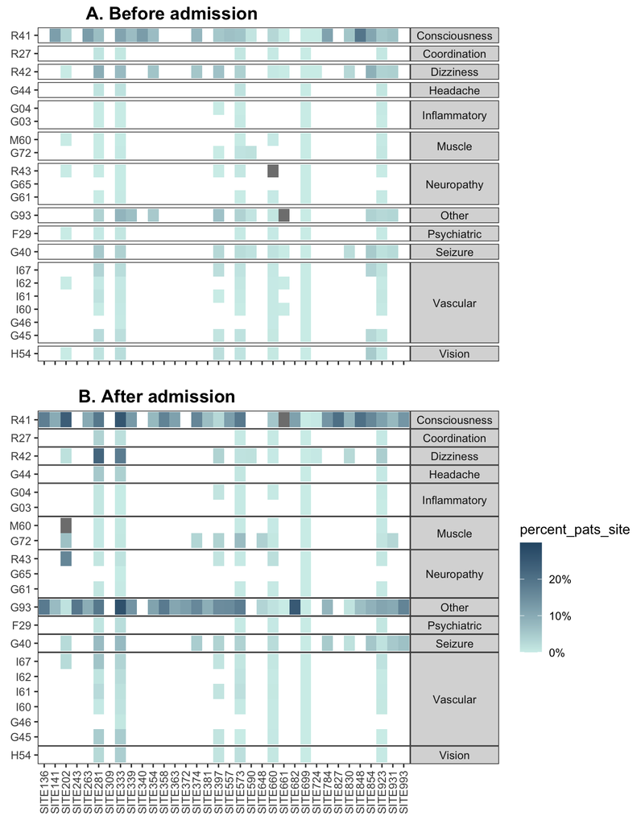

```r
code_prevalence <- diag_ana %>%
  group_by(SiteID, time, icd, `Neurological Disease Category`, full_icd) %>%
  summarise(pats_time_icd_site = sum(num_patients_icd), .groups = 'drop') %>%
  left_join(site_pats, by = 'SiteID') %>%
  mutate(percent_pats_site = pats_time_icd_site/total_patients_per_site,
         SiteID = as.factor(SiteID))

before_code_prev <- code_prevalence %>%
  filter(time == 'Before admission',
         SiteID != 'SITE309') %>%
  ggplot(aes(y = icd, x = SiteID, fill = percent_pats_site)) +
  geom_tile() +
  labs(y = NULL, x = NULL) +
  #f6d2a9,#f5b78e,#f19c7c,#ea8171,#dd686c,#ca5268,#b13f64
  scale_fill_gradient(
    # low = '#f6d2a9', high = '#b13f64',
    low = '#d1eeea', high = '#2a5674',
    labels = scales::percent_format(accuracy = 1),
    limits = c(0, 0.3),
    guide = guide_legend(override.aes = list(fill = "white"))) +
  scale_x_discrete(drop = F) +
  facet_grid(rows = vars(`Neurological Disease Category`), space = 'free', scale = 'free') +
  heat_theme_top() +
  NULL

after_code_prev <- code_prevalence %>%
  filter(time == 'After admission',
         SiteID != 'SITE309') %>%
  ggplot(aes(y = icd, x = SiteID, fill = percent_pats_site)) +
  geom_tile() +
  labs(y = NULL, x = NULL) +
  scale_x_discrete(drop = F) +
  #d1eeea,#a8dbd9,#85c4c9,#68abb8,#4f90a6,#3b738f,#2a5674
  scale_fill_gradient(low = '#d1eeea', high = '#2a5674',
                      labels = scales::percent_format(accuracy = 1),
                      limits = c(0, 0.3)) +
  facet_grid(rows = vars(`Neurological Disease Category`), space = 'free', scale = 'free') +
  heat_theme_bottom() +
  NULL

heats <- cowplot::plot_grid(before_code_prev, after_code_prev, ncol = 1,
                            rel_heights = c(1, 1.15),
                   labels = c('A. Before admission', 'B. After admission'))
heats
```

```r
ggsave('figs/icd_heatmap.png', heats, height = 10, width = 7)
```

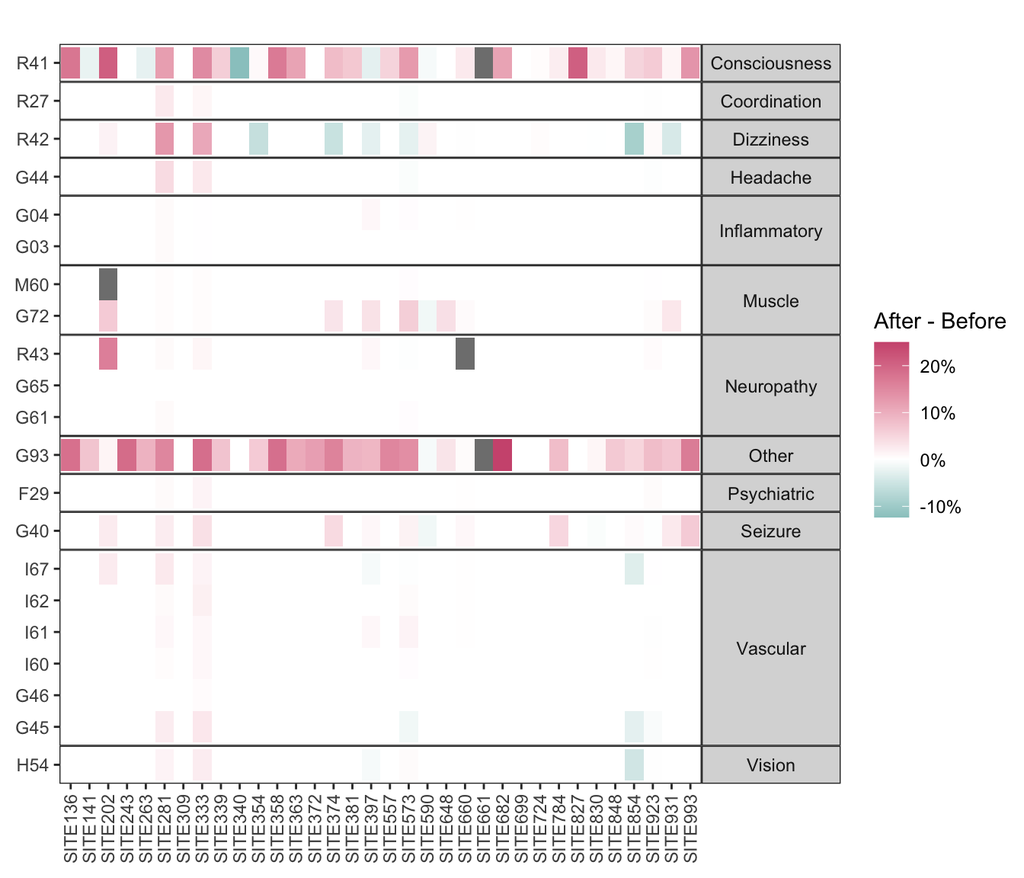

```r
diff_code <- code_prevalence %>%
  filter(SiteID != 'SITE309') %>%
  pivot_wider(names_from = time, values_from = percent_pats_site, id_cols = c(SiteID, icd, `Neurological Disease Category`), values_fill = 0) %>%
  mutate(percent_diff = `After admission` - `Before admission`)

diff_heat <- diff_code %>%
  ggplot(aes(y = icd, x = SiteID, fill = percent_diff)) +
  geom_tile() +
  labs(y = NULL, x = NULL, fill = 'After - Before') +
  scale_x_discrete(drop = F) +
  #009392,#39b185,#9ccb86,#e9e29c,#eeb479,#e88471,#cf597e
  scale_fill_gradient2(
    low = '#009392',
    high = '#cf597e',
    labels = scales::percent_format(accuracy = 1)) +
  facet_grid(rows = vars(`Neurological Disease Category`), space = 'free', scale = 'free') +
  heat_theme_bottom() +
  NULL
diff_heat
```

```r
ggsave('figs/icd_diff_heatmap.png', diff_heat, height = 5.5, width = 7)
```

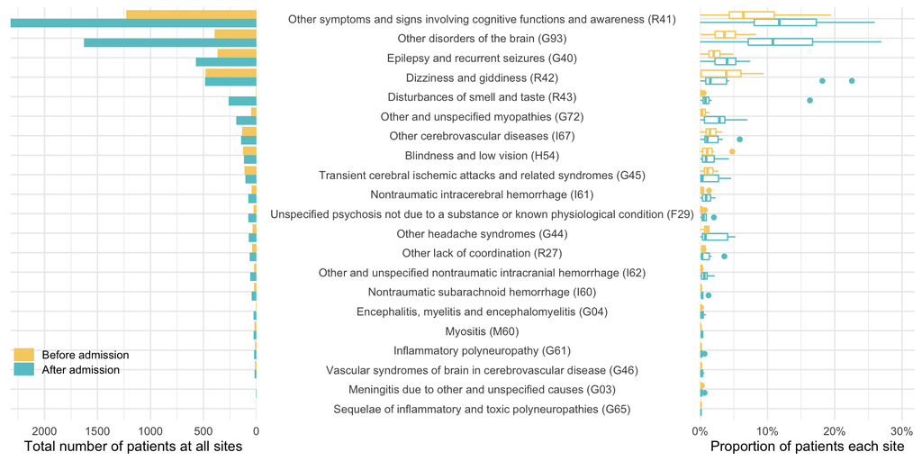

```r
icd_time <- diag_ana %>%
  filter(SiteID != 'SITE309') %>%
  group_by(full_icd, time) %>%
  summarise(pats_icd_time = sum(num_patients_icd, na.rm = T), .groups = 'drop')
sorted_icds <- icd_time %>%
  filter(time == 'After admission') %>%
  arrange(pats_icd_time) %>%
  pull(full_icd)

total_icd <- icd_time %>%
  ggplot(aes(x = pats_icd_time, y = fct_relevel(full_icd, sorted_icds), fill = time)) +
  scale_fill_carto_d(palette = 4, guide = guide_legend(reverse = TRUE)) +
  geom_col(position = 'dodge') +
  theme_minimal() +
  scale_x_reverse(expand = expansion(add = c(0,0))) +
  scale_y_discrete(labels = NULL) +
  theme(legend.position = c(0.25, 0.15),
        legend.title = element_blank(),
        legend.key.height = unit(4, 'mm')) +
  labs(x = 'Total number of patients at all sites', y = NULL)

percent_icd <- code_prevalence %>%
  filter(SiteID != 'SITE309') %>%
  ggplot(aes(x = percent_pats_site,
             y = fct_relevel(full_icd, sorted_icds),
             color = time)) +
  scale_color_carto_d(palette = 4, guide = NULL) +
  # scale_color_manual(values = c('#2a5674', '#b13f64')) +
  geom_boxplot(fill = 'white') +
  theme_minimal() +
  theme(legend.position = c(0.75, 0.1),
        legend.title = element_blank(),
        axis.text.y = element_text(hjust = 0.5)) +
  scale_x_continuous(expand = expansion(add = c(0, 0.05)),
                     labels = scales::percent_format(accuracy = 1)) +
  labs(x = 'Proportion of patients each site', y = NULL)

icd_prevalence_plots <- cowplot::plot_grid(total_icd, percent_icd, ncol = 2,
                   rel_widths = c(1, 2.5))
icd_prevalence_plots
```

```r
ggsave('figs/icd_prevalence.png', icd_prevalence_plots, height = 5, width = 10)
```

# Severity analysis

What ICD code has the most number severe patients? Sites with more severe patients?

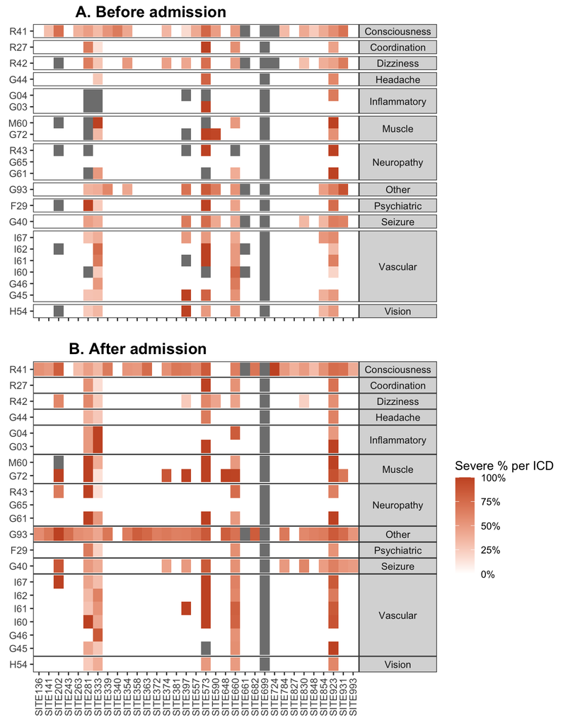

```r
severe_code <- diag_ana %>%
  filter(SiteID != 'SITE309') %>%
  mutate(percent_severe_site = num_patients_ever_severe_icd1/num_patients_icd,
         SiteID = as.factor(SiteID))

severe_bef_heat <- severe_code %>%
  filter(time == 'Before admission') %>%
  ggplot(aes(y = icd, x = SiteID, fill = percent_severe_site)) +
  geom_tile() +
  labs(y = NULL, x = NULL, fill = 'Severe % per ICD') +
  #3d5941,#778868,#b5b991,#f6edbd,#edbb8a,#de8a5a,#ca562c
  scale_fill_gradient(
    # low = '#f6d2a9', high = '#b13f64',
    low = 'white', high = '#ca562c',
    guide = guide_legend(override.aes = list(fill = "white")),
    ) +
  scale_x_discrete(drop = F) +
  facet_grid(rows = vars(`Neurological Disease Category`), space = 'free', scale = 'free') +
  heat_theme_top() +
  NULL

severe_aft_heat <- severe_code %>%
  filter(time == 'After admission') %>%
  ggplot(aes(y = icd, x = SiteID, fill = percent_severe_site)) +
  geom_tile() +
  labs(y = NULL, x = NULL, fill = 'Severe % per ICD') +
  scale_x_discrete(drop = F) +
  #3d5941,#778868,#b5b991,#f6edbd,#edbb8a,#de8a5a,#ca562c
  scale_fill_gradient(
    low = 'white', high = '#ca562c',
    labels = scales::percent_format(accuracy = 1)) +
  facet_grid(rows = vars(`Neurological Disease Category`), space = 'free', scale = 'free') +
  heat_theme_bottom() +
  NULL

severe_heats <- cowplot::plot_grid(severe_bef_heat, severe_aft_heat, ncol = 1,
                            rel_heights = c(1, 1.15),
                   labels = c('A. Before admission', 'B. After admission'))
severe_heats
```

```r
ggsave('figs/icd_severe_heatmap.png', severe_heats, height = 10, width = 7)
```

# Severity enrichment analysis

## Null hypothesis:

For each ICD code, the proportion of severe patients who were diagnosed with that ICD code is similar to the proportion of never-severe patients who were diagnosed with that same ICD code.

**Is “enrichment” the right word to use here?**

For the sake of simplicity in this notebook, we’re going to denote patients whose symptoms have been categorized as severe (based on respiratory status +/- requiring ICU) at least once as *severe patients*, and patients whose symptoms have NEVER been categorized as severe as *non-severe patients*.

For each ICD code, we computed the expected number of *severe patients* by multiplying the proportion of *non-severe patients* who were diagnosed with that code with the total number of *severe patients*. We performed an enrichment analysis to examine the difference of *severe patients* proportions across ICD codes. We calculated each ICD code’s enrichment by dividing the observed proportion of honorees by the expected proportion of honorees and reported a value of log2 enrichment (LOE) and its 95% confidence intervals. The 95% confidence interval of the LOE was estimated using the Poisson model method [@isbn:9780849394447].

## Before admission

```r
confusion_df <- diag_ana %>%
  filter(!SiteID %in% c('SITE660', 'SITE309'),
         time == 'Before admission') %>%
  group_by(full_icd) %>%
  summarise(across(contains('severe'), .fns = sum, na.rm = T), .groups = 'drop') %>%
  mutate(Observed = num_patients_ever_severe_icd1,
         num_non_severe = num_patients_never_severe_icd1 + num_patients_never_severe_icd0,
         num_severe = num_patients_ever_severe_icd1 + num_patients_ever_severe_icd0,
         Expected = num_patients_never_severe_icd1/num_non_severe*num_severe,
         over_sev = Observed - Expected)

nested_obs_exp <- confusion_df %>%
  select(full_icd,
         num_patients_never_severe_icd0,
         num_patients_never_severe_icd1,
         num_patients_ever_severe_icd0,
         num_patients_ever_severe_icd1) %>%
  group_by(full_icd) %>%
  nest()

fish_obs_exp <- nested_obs_exp %>%
  mutate(fish = map(data, my_fish)) %>%
  dplyr::select(-data) %>%
  unnest(cols = c(fish)) %>%
  mutate(upper = ifelse(is.na(upper), Inf, upper))
```

### Country enrichment table

The full table with all ICD codes and their corresponding enrichment can be browsed interactively below:

```r
library(DT)
fish_obs_exp %>%
  mutate(ci = paste0('(', round(log2(lower), 1), ', ',
                     round(log2(upper), 1), ')'),
         lestimate = log2(estimate)) %>%
  left_join(confusion_df, by = 'full_icd') %>%
  select(full_icd, Observed, Expected, over_sev,
         estimate, lestimate, ci) %>%
  rename('ICD' = 'full_icd',
         'Observed - Expected' = 'over_sev',
         'Enrichment' = 'estimate',
         'Log2(enrichment)' = 'lestimate',
         '95% Confidence interval' = 'ci') %>%
  datatable(rownames = FALSE) %>%
  formatRound(c('Observed', 'Expected', 'Observed - Expected',
                'Enrichment', 'Log2(enrichment)'), 1) %>%
  {.}
```

| ICD | Observed | Expected | Observed - Expected | Enrichment | Log2(enrichment) | 95% Confidence interval |
| --- | --- | --- | --- | --- | --- | --- |
| Blindness and low vision (H54) | 33 | 42.8523676880223 | -9.85236768802228 | 0.770085803432137 | -0.376908894158392 | (-1, 0.3) |
| Disturbances of smell and taste (R43) | 4 | 0.829609996213555 | 3.17039000378644 | 4.82154267457782 | 2.26949481717687 | (-1.1, 7.9) |
| Dizziness and giddiness (R42) | 195 | 185.692613734648 | 9.30738626535202 | 1.05012254433907 | 0.0705576934098173 | (-0.2, 0.3) |
| Encephalitis, myelitis and encephalomyelitis (G04) | 2 | 0.767177071063997 | 1.232822928936 | 2.60696008188332 | 1.38236849230581 | (-2.9, 7.3) |
| Epilepsy and recurrent seizures (G40) | 107 | 88.8037293039704 | 18.1962706960296 | 1.20490435298888 | 0.268918627828369 | (-0.1, 0.7) |
| Inflammatory polyneuropathy (G61) | 4 | 0.761541549578483 | 3.23845845042152 | 5.25250395361097 | 2.39300534282936 | (-0.9, 8) |
| Meningitis due to other and unspecified causes (G03) | 1 | 0.761541549578483 | 0.238458450421517 | 1.31312598840274 | 0.393005342829361 | (-5.9, 6.7) |
| Myositis (M60) | 6 | 0 | 6 |  |  | (0.5, Inf) |
| Nontraumatic intracerebral hemorrhage (I61) | 12 | 7.67177071063997 | 4.32822928936003 | 1.56417604912999 | 0.645402898139603 | (-0.7, 2) |
| Nontraumatic subarachnoid hemorrhage (I60) | 2 | 5.29194499017682 | -3.29194499017682 | 0.377932877932878 | -1.40379806486459 | (-4.7, 1) |

[output cut: 11 more lines]

### Compute enrichment from proportion comparisons

```r
filtered_obs_exp <- confusion_df %>%
  left_join(fish_obs_exp, by = 'full_icd') %>%
  mutate(
    distance_to_null = case_when(
      lower > 1 ~ lower - 1,
      TRUE ~ upper - 2
    ),
    presentation = case_when(
      lower > 1 ~ '#ca562c',
      upper < 1 ~ '#009392',
      TRUE ~ 'grey20'
    ),
    full_icd =  as.factor(full_icd) %>% fct_reorder(num_patients_ever_severe_icd1)) %>%
  arrange(desc(num_patients_ever_severe_icd1)) %>%
  {.}

plot_obs_exp <- filtered_obs_exp %>%
  mutate(lestimate = log2(estimate),
         llower = log2(lower),
         lupper = log2(upper)) %>%
  select(full_icd, lestimate, llower, lupper, presentation, over_sev, Observed, Expected) %>%
  pivot_longer(- c(full_icd, presentation, over_sev), names_to = 'type') %>%
  mutate(subtype = ifelse(type == 'Expected' | type == 'Observed',
                          'Sqrt(number of honorees)',
                          'Log2 enrichment, 95% CI'))
```

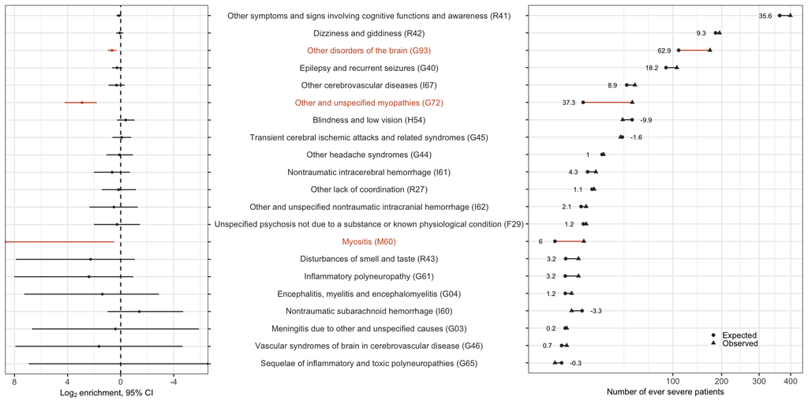

```r
plot_obs_exp_right <- plot_obs_exp %>% filter(subtype == 'Sqrt(number of honorees)')
plot_obs_exp_left <- plot_obs_exp %>% filter(subtype != 'Sqrt(number of honorees)')
sorted_icds <- rev(as.character(filtered_obs_exp$full_icd))
plot_obs_exp_before <- plot_obs_exp_left

enrichment_plot_left <- plot_obs_exp_left %>%
  ggplot(aes(x = fct_relevel(full_icd, sorted_icds))) +
  geom_pointrange(
    data = plot_obs_exp_left %>%
      pivot_wider(names_from = type),
    aes(y = lestimate,
        ymin = llower,
        ymax = lupper,
        group = full_icd),
    color = filtered_obs_exp$presentation,
    stroke = 0.3, fatten = 2
  ) +
  coord_flip() +
  labs(x = NULL, y = bquote(Log[2] ~ 'enrichment, 95% CI')) +
  theme(
    legend.position = c(0.9, 0.3),
    axis.title = element_text(size = 9),
    plot.margin = margin(5.5, 2, 5.5, 5.5, unit = 'pt')
  ) +
  scale_color_brewer(type = 'qual', palette = 'Set1') +
  scale_x_discrete(position = 'top', labels = NULL) +
  scale_y_reverse() +
  geom_hline(data = plot_obs_exp_left, aes(yintercept = 0), linetype = 2)

over_severe_icds <- plot_obs_exp_right %>%
  filter(over_sev > 0) %>%
  pull(full_icd)

enrichment_plot_right <- plot_obs_exp_right %>%
  ggplot(aes(x = fct_relevel(full_icd, sorted_icds),
             y = value)) +
  geom_line(aes(group = full_icd, color = presentation)) +
  scale_color_manual(values = rev(unique(plot_obs_exp_right$presentation)),
                     guide = NULL) +
  geom_point(aes(shape = type), color = 'grey20') +
  labs(x = NULL, y = 'Number of ever severe patients') +
  theme(
    axis.title = element_text(size = 9),
    legend.position = c(0.75 , 0.1),
    axis.text.y = element_text(
      color = rev(filtered_obs_exp$presentation),
      hjust = 0.5),
    legend.background = element_blank(),
    legend.key.height = unit(3, 'mm'),
    legend.key.width = unit(3, 'mm'),
    plot.margin = margin(5.5, 5.5, 8.5, 2, unit = 'pt')
  ) +
  scale_y_sqrt() +
  coord_flip() +
  geom_text(
    data = . %>%
      filter(type == 'Expected', !(full_icd %in% over_severe_icds)),
    nudge_y = 1.2, aes(label = round(over_sev, 1)), size = 2.5) +
  geom_text(
    data = . %>%
      filter(type == 'Expected', full_icd %in% over_severe_icds),
    nudge_y = -1.2, aes(label = round(over_sev, 1)), size = 2.5)

enrichment_plot <- cowplot::plot_grid(enrichment_plot_left, enrichment_plot_right,
                                rel_widths = c(1, 2.8))
enrichment_plot
```

```r
ggsave('figs/icd_severe_bef.png', enrichment_plot, width = 9.5, height = 5)
```

## After admission

### Country enrichment table

The full table with all ICD codes and their corresponding enrichment can be browsed interactively below:

| ICD | Observed | Expected | Observed - Expected | Enrichment | Log2(enrichment) | 95% Confidence interval |
| --- | --- | --- | --- | --- | --- | --- |
| Blindness and low vision (H54) | 27 | 31.4542599136239 | -4.45425991362387 | 0.858389295254263 | -0.220296010148806 | (-1, 0.5) |
| Disturbances of smell and taste (R43) | 47 | 29.0363498674744 | 17.9636501325256 | 1.61866075503684 | 0.694800651909541 | (0, 1.4) |
| Dizziness and giddiness (R42) | 180 | 195.286295313882 | -15.2862953138815 | 0.921723665814275 | -0.117593801622921 | (-0.4, 0.2) |
| Encephalitis, myelitis and encephalomyelitis (G04) | 4 | 3.83588535531998 | 0.164114644680016 | 1.04278403275333 | 0.0604403974184473 | (-2.3, 2.3) |
| Epilepsy and recurrent seizures (G40) | 178 | 123.731538870197 | 54.2684611298034 | 1.43859844971891 | 0.524663954522571 | (0.2, 0.8) |
| Inflammatory polyneuropathy (G61) | 8 | 0.761541549578483 | 7.23845845042152 | 10.5050079072219 | 3.39300534282936 | (0.5, 8.9) |
| Meningitis due to other and unspecified causes (G03) | 5 | 0.761541549578483 | 4.23845845042152 | 6.56562994201371 | 2.71493343771672 | (-0.4, 8.3) |
| Myositis (M60) | 11 | 2.57005218787635 | 8.42994781212365 | 4.28006872852234 | 2.09763396333255 | (0.2, 4.6) |
| Nontraumatic intracerebral hemorrhage (I61) | 24 | 10.740478994896 | 13.259521005104 | 2.23453721304284 | 1.15997607096936 | (0.2, 2.2) |
| Nontraumatic subarachnoid hemorrhage (I60) | 16 | 6.85387394620634 | 9.14612605379366 | 2.33444620160487 | 1.22308034138705 | (0, 2.6) |

[output cut: 11 more lines]

### Compute enrichment from proportion comparisons

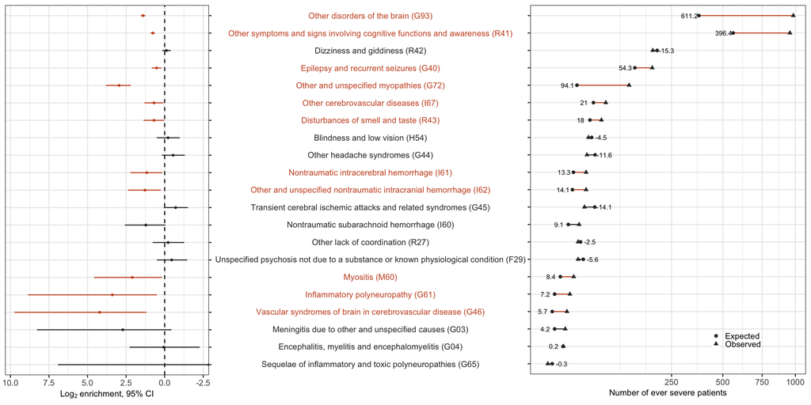

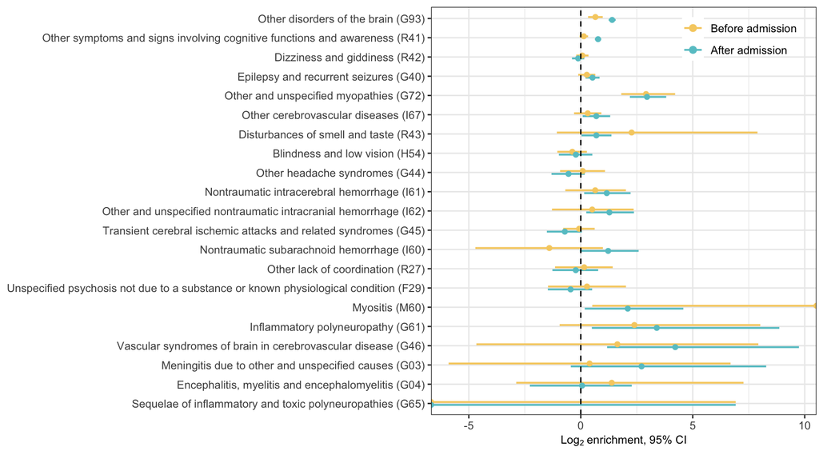

```r
enrichment_time <- plot_obs_exp_before %>%
  mutate(time = 'Before admission') %>%
  bind_rows(plot_obs_exp_after %>% mutate(time = 'After admission'))

plot_enrich_both <- enrichment_time %>%
  pivot_wider(names_from = type) %>%
  ggplot(aes(y = fct_relevel(full_icd, sorted_icds))) +
  ggstance::geom_pointrangeh(
    aes(x = lestimate,
        xmin = llower,
        xmax = lupper,
        color = time),
    position = position_dodge(width = 0.3),
    stroke = 0.1, fatten = 3, size = 0.7
  ) +
  labs(y = NULL, x = bquote(Log[2] ~ 'enrichment, 95% CI')) +
  theme(
    legend.position = c(0.8, 0.93),
    legend.background = element_blank(),
    axis.title = element_text(size = 9),
    plot.margin = margin(5.5, 2, 5.5, 5.5, unit = 'pt')
  ) +
  scale_color_carto_d(palette = 4, guide = guide_legend(reverse = TRUE)) +
  geom_vline(aes(xintercept = 0), linetype = 2)
plot_enrich_both
```

```r
ggsave('figs/icd_severe.png', plot_enrich_both, width = 9, height = 5)
```